# Simulations

Julian Frattini

2025-04-08

This notebook explains the fundamentals of **data set simulations**, a powerful tool to create a reliable ground truth. As a running example, we consider studying the effect of a novel `technique` on the number of found `defects`.

## Dataset Simulation

We simulate a data set by drawing randomly from certain distributions (e.g., `stats::rnorm` to draw from a normal distribution or `stats::rpois` from a Poisson distribution). Independent variables simply sample randomly from a distribution. Dependent variables sample from a distribution where one of the parameters is affected by an independent variable.

```r
n <- 1000
effect.strength <- 5

d <- data.frame(
  technique = rep(0:1, n/2) # simulation of an independent variable
) %>% mutate(
  defects = rpois(n, 10 + effect.strength*technique), # simulation of a dependent variable
  technique = factor(technique, levels = c(0, 1), ordered = FALSE)
)
```

## Visualization

To confirm, we can plot the distribution of the simulated variables

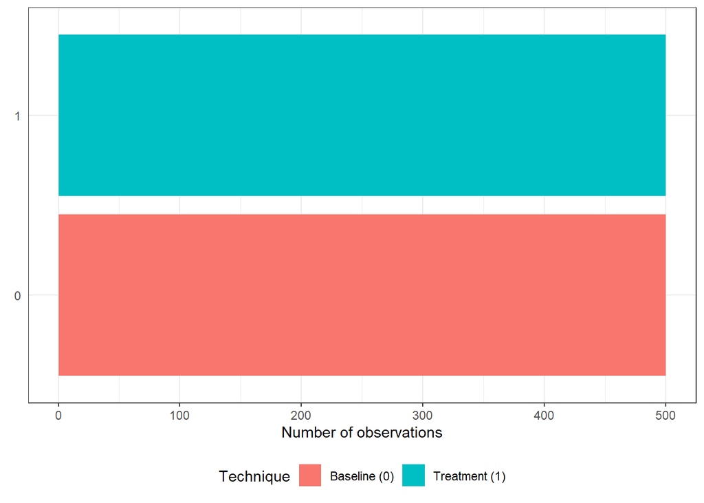

```r
ggplot(data = d, mapping = aes(y = technique, fill = technique)) +
  geom_histogram(stat = "count") +
  labs(x = "Number of observations", y = element_blank(), fill = "Technique") +
  scale_fill_discrete(labels=c("Baseline (0)", "Treatment (1)")) +
  theme_bw() +
  theme(axis.ticks.y = element_blank(), legend.position = "bottom")
```

```r
ggsave(filename = "simulation-marginal-technique.png",
       device = "png", units = "cm", width = 10, height = 3)
```

Next, we can visualize the distribution of the dependent variable. If we visualize the dependent variable as is, the resulting distribution may be interpreted to stem from a single population.

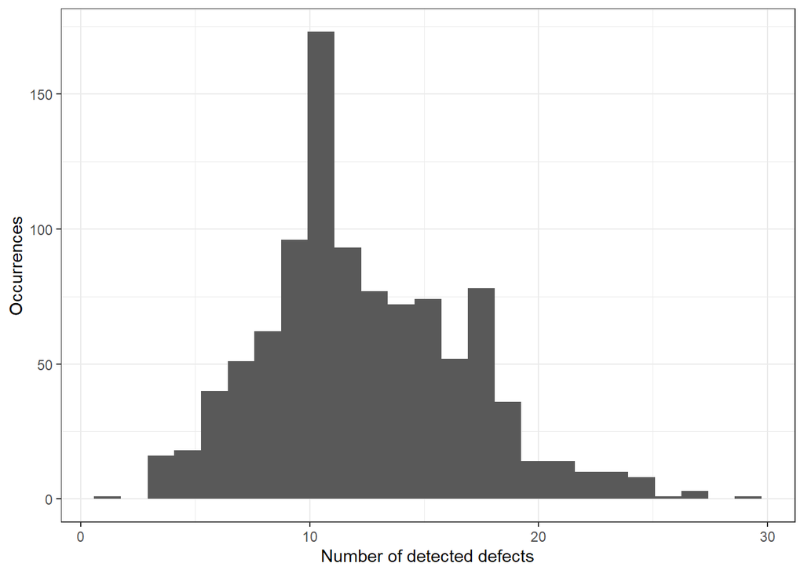

```r
ggplot(data = d, mapping = aes(x = defects)) +
  geom_histogram(stat = "bin", bins = 25) +
  labs(x = "Number of detected defects", y = "Occurrences") +
  theme_bw()
```

```r
ggsave(filename = "simulation-defects-combined.png",
       device = "png", units = "cm", width = 10, height = 5.5)
```

However, if we stratify the distribution by the independent variable `technique` we see that the response variable stems from two populations. One has its mean at 10, the other at 15.

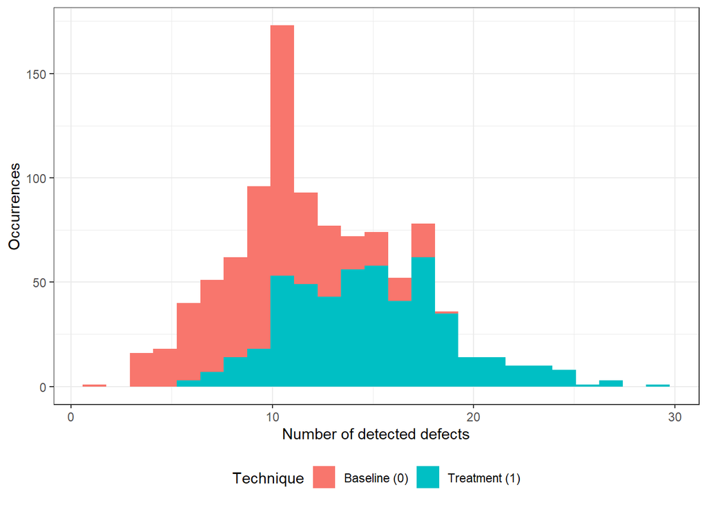

```r
ggplot(data = d, mapping = aes(x = defects, fill = technique)) +
  geom_histogram(stat = "bin", bins = 25) +
  labs(x = "Number of detected defects", y = "Occurrences", fill = "Technique") +
  scale_fill_discrete(labels=c("Baseline (0)", "Treatment (1)")) +
  theme_bw() +
  theme(legend.position="bottom")
```

```r
ggsave(filename = "simulation-defects-split.png",
       device = "png", units = "cm", width = 10, height = 7)
```

## Analysis

This effect can also be confirmed analytically using a regression model. Under the assumption that `technique` influences `defects`, we can regress the latter on the former.

```r
results <- lm(defects ~ technique, data = d)
confint(results)
```

```
##                2.5 %    97.5 %
## (Intercept) 9.550038 10.189962
## technique1  4.595506  5.500494
```

The confidence interval of the effect that the `technique` has on the number of detected `defects` (`technique1`) covers the simulated effect. We can also visualize this overlap.

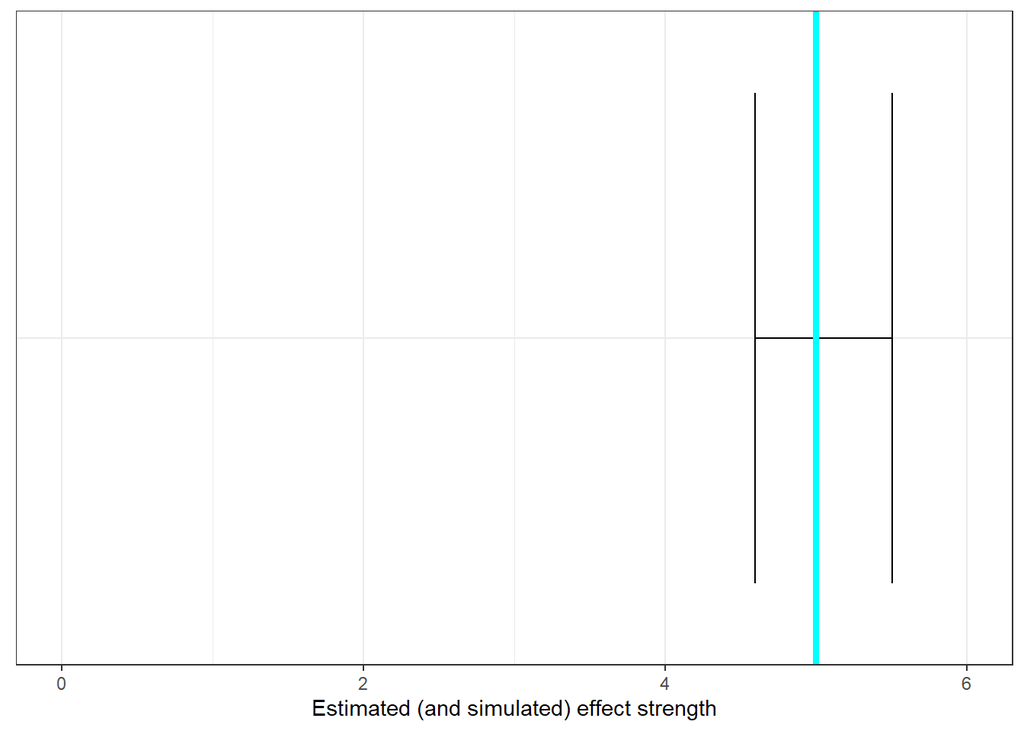

```r
cis <- data.frame(confint(results)) %>%
  rename(all_of(c(lower = "X2.5..", upper = "X97.5..")))

cbind(factor = rownames(cis), cis) %>%
  filter(factor == "technique1") %>%
  ggplot(aes(y = TRUE)) +
    geom_errorbar(aes(xmin = lower, xmax = upper)) +
    geom_vline(xintercept = effect.strength,
               color="cyan", size = 1.5) +
    xlim(0, 6) +
    labs(x = "Estimated (and simulated) effect strength") +
    theme_bw() +
    theme(axis.title.y = element_blank(),
          axis.ticks.y = element_blank(),
          axis.text.y = element_blank())
```

```r
ggsave(filename = "regression.png",
       device = "png", units = "cm", width = 8, height = 3)
```

The overlap of confidence interval with the simulated ground truth acts as evidence that our statistical model succeeds in revealing the actual effect of interest. It is worth noting, however, that the analysis makes some questionable assumptions (e.g., `lme4::lm` conducts a linear regression assuming normal distribution, yet the dependent variable follows a Poisson distribution).